# 第2回「圏論と認知科学」ワークショップ

**Workshop: Category theory and cognitive science II**

**2020年2月25日（火）9:00-18:00 @長浜バイオ大学（滋賀県）**

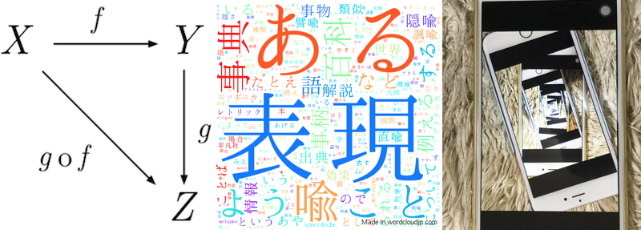

参加人数の把握のため、**2020年2月7日（金）まで**に参加登録をお願い致します。

- 登録フォーム→ https://tinyurl.com/u2dqw8v

**お知らせ**

認知科学論文誌特集号**「圏論は認知科学に貢献できるか」**の原稿を募集中です。

- 詳細は https://www.jcss.gr.jp/news/jcss/entry-358.html を御覧ください。
- 2020年04月13日（月）プロポーザル投稿締切
- 2021年03月初旬 28巻1号掲載

## 開催概要

- 日程 | 2020年2月25日（火）9:00-18:00
- 会場 | 長浜バイオ大学大講義室2 (命北館5階） [キャンパスマップ](https://www.nagahama-i-bio.ac.jp/introduction/%E3%82%AD%E3%83%A3%E3%83%B3%E3%83%91%E3%82%B9%E3%83%9E%E3%83%83%E3%83%97/) / [アクセス](https://www.nagahama-i-bio.ac.jp/others/%E4%BA%A4%E9%80%9A%E3%82%A2%E3%82%AF%E3%82%BB%E3%82%B9/) )
- 企画 | 日髙昇平（JAIST）・高橋康介（中京大学）・高橋達二（東京電機大学）・布山美慕（早稲田大学）
- スペシャルゲスト | 西郷さん（長浜バイオ大学）
- 参加登録 | https://tinyurl.com/u2dqw8v (Googleフォーム) 締め切り 2020年2月7日（金）
- 問い合わせ先 | メールにて jcss2017homoqualitas@gmail.com までお願い致します。

※ ワークショップ終了後、長浜駅にて懇親会を開催予定です。

## スケジュール

| 時間 | 内容 |
| --- | --- |
| 09:00-12:00 | **圏論チュートリアル** 圏論入門・『圏論の道案内』に関する対談 |
| 12:00-13:00 | 昼ごはん（各自） |
| 13:00-18:00 | **認知科学と圏論** |
| 13:00-14:00 | 招待講演「比喩理解における類推と概念融合（仮）」（寺井あすか） |
| 14:00-15:00 | 「圏論による比喩理解の理解」（高橋達二・布山美慕・池田駿介・西郷甲矢人） |
| 15:00-15:10 | 休憩 |
| 15:10-16:10 | オープンディスカッション「圏論は比喩理解に何をもたらすか？」 |
| 16:10-17:10 | 「圏論によるオブジェクト認知の理解」（日髙昇平） |
| 17:10-18:00 | 総合議論「圏論は結局、認知科学に何をもたらすか？」 |

## 開催趣旨

[2018年認知科学会OS「意味理解とオブジェクト認知 : ホモ・クオリタスとしての人間理解へ向けて」](http://kohske.github.io/research/JCSS2018OS/)にて、西郷さんをお招きして、認知科学への圏論の導入の試みを紹介しました。

その後、2019年の初頭の[「圏論による認知モデリングの可能性」（2019年1月）](https://kohske.github.io/research/201901CTWS/)の開催に始まり、[2019年認知科学会OS「圏論による認知モデリングの可能性：ホモ・クオリタスとしての人間理解へ向けて」](https://www.jcss.gr.jp/meetings/jcss2019/program.html#OS01)の開催、認知科学誌上討論[「誌上討論：圏論的アプローチで意識は理解できるか」](https://www.jcss.gr.jp/publishing/journals/journal_backnumber/entry-361.html)の刊行、認知科学論文誌の圏論特集号[「圏論は認知科学に貢献できるか」](https://www.jcss.gr.jp/news/jcss/entry-358.html)の企画など、認知科学と圏論の蜜月関係は（一部で）ますます盛り上がりの様相を見せつつあります。

今回の2020「圏論と認知科学」WSでは、圏論を用いた認知科学研究の意義や可能性を更に模索するべく、圏論チュートリアルおよびトピックを絞った圏論による認知研究事例に関するディスカッションを行います。

午前中の圏論チュートリアルでは、JAIST日髙氏（予定）によるチュートリアルに続き、西郷さんの[「圏論の道案内」](https://gihyo.jp/book/2019/978-4-297-10723-9)をベースに、初学者がハマりやすい落とし穴などを取り上げます。例えば可換図式に矢印が一本だからといって、射がひとつしかないとは限りません。このような落とし穴についてアレコレ議論を重ねてきた「圏論の道案内」ヘビーユーザー達による対談も企画しています。また参加者で演習問題を解くという時間も設けられるかもしれません。

午後の「認知科学と圏論」セッションでは比喩理解とオブジェクト認知をテーマとして取り上げ、圏論を用いた研究事例を紹介します。その事例をベースに、圏論を用いる意義や可能性、問題点などを議論する予定です。これらのトピックに興味がある方にとっては、直接的に有意義なセッションとなると思います。また、これ以外のトピックを研究対象としている方にとっては、ご自身の研究を圏論的視点で捉え直すことの意義や可能性について洞察を得ることができるかもしれませんが、余計混乱するかもしれません。

参加者がいなくても開催しますが、幅広い皆様の参加をお待ちしております。

## 関連資料

- 圏論の演習問題 (PDF 156KB)
- 本ワークショップはどなたでも参加可能です。
- 協賛：科研費「限定合理性を備えた深層強化学習理論の展開」